# Informe metodológico: Free-ranging bustard classification — ROBUST UNIFIED SCRIPT

Cristy Medina

2026-05-19

# Resumen

Este documento describe el funcionamiento del script **Free-ranging bustard classification — ROBUST UNIFIED SCRIPT**, un flujo de trabajo diseñado para aplicar un modelo de clasificación previamente entrenado en cautividad a datos de acelerometría registrados en libertad. El script procesa la señal ACC, construye ventanas de 2 segundos, extrae *features* mediante `rabc`, aplica un modelo Random Forest ya entrenado y genera predicciones, probabilidades, diagnósticos de confianza y presupuestos temporales de comportamiento.

La versión robusta del script unifica en un solo archivo la predicción a **20 Hz** y a **10 Hz**, incorporando mecanismos de control de calidad, conversión opcional de frecuencia mediante filtro Butterworth y decimación, manejo seguro de la extracción de *features*, predicción probabilística protegida ante errores comunes, interpretación de confianza mediante calibración y exportación sistemática de tablas, figuras y ficheros Excel. Estas mejoras aumentan la reproducibilidad, la trazabilidad y la robustez del análisis aplicado a datos de individuos en libertad.

# 1. Introducción

La acelerometría triaxial se ha convertido en una herramienta clave para estudiar el comportamiento animal de forma continua y remota. En el caso del sisón común, la clasificación automática del comportamiento a partir de datos ACC resulta especialmente valiosa porque permite analizar actividad, uso del espacio y patrones temporales en individuos en libertad sin depender exclusivamente de observación directa.

El script descrito en este informe se sitúa en la fase de **aplicación del modelo**. A diferencia de los scripts de entrenamiento en cautividad, este flujo no ajusta modelos nuevos, sino que reutiliza un modelo Random Forest ya entrenado con datos etiquetados. Su función es transformar los datos libres en una estructura compatible con el modelo cautivo, generar predicciones por ventana y resumirlas de forma interpretable mediante métricas de confianza y presupuestos temporales.

# 2. Objetivo general del script

El objetivo principal del script es aplicar de forma robusta y reproducible un modelo cautivo ya entrenado a datos de acelerometría en libertad, produciendo:

- predicción de comportamiento por ventana de 2 segundos;
- probabilidades por clase;
- medidas de confianza del modelo;
- estimación de corrección esperada basada en calibración cautiva;
- presupuestos temporales por hora, día y mes;
- archivos de salida en CSV, PNG y Excel.

# 3. Qué hace este script y qué no hace

**Importante.** Este script **no entrena modelos**. Únicamente reutiliza un modelo ya entrenado en cautividad y lo aplica a datos en libertad.

## 3.1. Qué hace

1. Lee datos ACC en libertad.
2. Filtra registros de tipo `SENSORS`.
3. Construye bursts completos y ventanas de 2 segundos.
4. Convierte las ventanas al formato esperado por el modelo.
5. Opcionalmente transforma ventanas de 20 Hz a 10 Hz.
6. Elimina ventanas con señal inválida.
7. Extrae *features* temporales y frecuenciales.
8. Aplica el modelo cautivo.
9. Genera probabilidades y clases predichas.
10. Estima corrección esperada mediante calibración.
11. Resume los comportamientos como presupuestos temporales.
12. Exporta todos los resultados.

# 4. Principales diferencias y ventajas del script robusto

Este script robusto presenta varias mejoras importantes frente a versiones más simples del pipeline libre:

## 4.1. Unificación de modos 20 Hz y 10 Hz

El script soporta dos modos de predicción:

- **20 Hz**: usa directamente ventanas de 40 puntos por eje.
- **10 Hz**: primero aplica filtro Butterworth y después decimación para convertir 40 puntos en 20.

Esto permite usar modelos cautivos entrenados a distintas frecuencias sin mantener scripts completamente separados.

## 4.2. Coherencia entre frecuencia del modelo y frecuencia de entrada

El script fuerza a que la frecuencia de las ventanas libres coincida con la frecuencia usada durante el entrenamiento cautivo. Esto es esencial para que las *features* calculadas sean comparables y para evitar errores metodológicos al aplicar el modelo.

## 4.3. Procesado robusto de señal

La versión robusta incorpora:

- verificación de columnas obligatorias;
- eliminación de columnas sin nombre;
- conservación exclusiva de bursts completos;
- ventanas estrictamente completas;
- conversión explícita de ACC de mg a g;
- filtrado de ventanas con NA/NaN/Inf;
- extracción de *features* segura.

## 4.4. Predicción probabilística segura

El script implementa una función de predicción protegida que reintenta el cálculo de probabilidades si detecta problemas con columnas como `label` o con tipos de datos incompatibles.

## 4.5. Interpretación ecológica de la confianza

La confianza del modelo no se resume solo con `pmax`. Además, se estima una **expected correctness** basada en calibración cautiva, lo que permite interpretar las predicciones en términos de fiabilidad esperada.

## 4.6. Salidas completas y trazables

El script genera de forma sistemática:

- CSV de predicciones;
- CSV de probabilidades;
- tablas de cobertura;
- presupuestos temporales;
- figuras PNG;
- un workbook Excel consolidado.

# 5. Estructura general del script

El flujo del script puede resumirse en los siguientes bloques:

1. Carga de paquetes.
2. Configuración.
3. Parámetros derivados según el modo.
4. Lectura de datos y funciones auxiliares.
5. Construcción de bursts y ventanas.
6. Conversión opcional 20 Hz → 10 Hz.
7. Control de calidad de la señal.
8. Extracción de *features*.
9. Predicción y probabilidades.
10. Calibración y corrección esperada.
11. Cobertura frente a confianza.
12. Construcción de presupuestos temporales.
13. Exportación de salidas.

# 6. Sección 0: paquetes

## Qué hace esta sección

La primera parte del script carga las librerías necesarias para:

- manipulación de datos (`dplyr`, `tidyr`);
- manejo temporal (`lubridate`);
- visualización (`ggplot2`);
- extracción de *features* (`rabc`);
- exportación Excel (`openxlsx`);
- compatibilidad con modelos entrenados en `caret`;
- procesado de señal (`signal`).

## Por qué es importante

Cada paquete cubre una parte específica del flujo. En particular, `signal` solo es necesario en modo 10 Hz, ya que se usa para el filtro Butterworth y `rabc` es esencial para construir las *features* que el modelo necesita.

# 7. Sección 1: configuración

## Qué hace esta sección

La lista `cfg` concentra todos los parámetros relevantes del script:

- frecuencia objetivo (`target_hz`);
- rutas a los modelos y calibraciones cautivas;
- claves de identificación del modelo;
- archivo CSV libre;
- parámetros del sensor;
- zonas horarias;
- umbrales de confianza;
- opciones del filtro Butterworth;
- carpeta de salida.

## Por qué es importante

Centralizar la configuración mejora mucho la reproducibilidad. En lugar de modificar parámetros dispersos a lo largo del código, todos los cambios se realizan en un único bloque. Esto facilita repetir el análisis con otros individuos, otros modelos o distintos umbrales de confianza.

## Código representativo

```r
cfg <- list(
  target_hz = 20,
  models_rds = "C:/Users/kuris/OneDrive/Documentos/results/captive/models_all.RDS",
  calibration_rds = "C:/Users/kuris/OneDrive/Documentos/results/captive/calibration_top_test_all.RDS",
  model_key_short = "rd_both_up",
  model_key_long  = "Model_rd_both_up_tested_on_both",
  free_csv = "C:/Users/kuris/OneDrive/Documentos/ACC/data/en libertad/Goku_221996_20230417_20230531.csv",
  pmax_threshold = 0.80,
  expected_correctness_threshold = 0.90
)
```

# 8. Sección 2: parámetros derivados según el modo

## Qué hace esta sección

Esta parte del script traduce el valor de `target_hz` en parámetros concretos:

- si `target_hz = 20`, entonces:
  - `points_segm = 40`
  - `feature_hz = 20`
  - `mode_label = "20Hz"`
- si `target_hz = 10`, entonces:
  - `points_segm = 20`
  - `feature_hz = 10`
  - `mode_label = "10Hz"`

## Por qué es importante

Esta lógica asegura que el resto del flujo utilice automáticamente la estructura adecuada según el modelo elegido. De este modo, un único script puede trabajar en ambos modos sin duplicar todo el pipeline.

# 9. Sección 3: lectura de datos y funciones auxiliares

## 9.1. `read_free_stream()`

### Qué hace

- lee el CSV libre;
- elimina columnas sin nombre;
- comprueba que existan columnas obligatorias;
- convierte `UTC_datetime` a fecha-hora.

### Por qué es importante

Es un control inicial de integridad. Si faltan columnas clave (`device_id`, `datatype`, `acc_x`, `acc_y`, `acc_z`), el análisis no puede continuar de forma segura.

## 9.2. `write_sheet()`

### Qué hace

Permite reemplazar o crear hojas en un workbook Excel sin producir conflictos por nombres duplicados.

### Por qué es importante

Simplifica la exportación final y evita errores cuando el archivo Excel ya existe.

# 10. Sección 4: construcción de bursts y ventanas

## 10.1. `add_burst_and_window_by_blocks()`

### Qué hace

A partir del flujo continuo de filas `SENSORS`, esta función:

- ordena los datos por dispositivo y tiempo;
- asigna un identificador de burst de 4 segundos (`burst_ID`);
- asigna un identificador de ventana de 2 segundos (`segm_ID`);
- define la posición del punto dentro de cada ventana (`n_comp`);
- elimina bursts incompletos.

### Por qué es importante

Este bloque reproduce en datos libres la misma estructura de ventanas usada durante el entrenamiento cautivo.

## 10.2. `pivot_windows_strict()`

### Qué hace

- convierte la aceleración de mg a g;
- verifica que las ventanas tengan todos los puntos esperados;
- reordena la señal en formato ancho:
  - `x1...xN`
  - `y1...yN`
  - `z1...zN`

### Por qué es importante

El modelo cautivo no trabaja con el formato largo original. Necesita una tabla con una fila por ventana y columnas de señal explícitas.

# 11. Sección 5: conversión opcional de 20 Hz a 10 Hz

Esta sección solo se usa cuando el modelo cautivo fue entrenado a 10 Hz.

## 11.1. `butter_lowpass_filtfilt()`

### Qué hace

Aplica un filtro paso bajo Butterworth con fase cero a una señal numérica.

### Por qué es importante

Antes de reducir frecuencia, es necesario eliminar componentes altas que podrían producir aliasing. La función `filtfilt()` evita desfase temporal porque filtra hacia delante y hacia atrás.

## 11.2. `downsample_window_40_to_20()`

### Qué hace

- convierte una ventana de 40 puntos en una de 20;
- opcionalmente la filtra antes;
- decima por 2 conservando una muestra de cada dos.

### Por qué es importante

Convierte cada ventana al formato exacto que espera un modelo entrenado a 10 Hz.

## 11.3. `downsample_free_windows_20_to_10()`

### Qué hace

- aplica la conversión anterior a todas las ventanas;
- genera nuevas columnas `x1..x20`, `y1..y20`, `z1..z20`;
- preserva la metadata original.

### Por qué es importante

Garantiza compatibilidad entre datos libres y modelo cautivo.

# 12. Sección 6: control de calidad de la señal

## Función `keep_only_finite_signal_windows()`

### Qué hace

- identifica las columnas de señal esperadas;
- fuerza su conversión a numérico;
- elimina cualquier ventana con NA, NaN o Inf.

### Por qué es importante

Las *features* de `rabc` requieren datos numéricos válidos. Si una ventana contiene valores no finitos, puede provocar errores o producir variables irrelevantes.

# 13. Sección 7: extracción de *features*

## Función `features_rabc_time_freq_safe()`

### Qué hace

- toma las ventanas ACC ya limpias;
- calcula *features* temporales con `calculate_feature_time()`;
- calcula *features* frecuenciales con `calculate_feature_freq()`;
- elimina de forma segura las ventanas que fallen;
- elimina también las *features* no finitas.

### Por qué es importante

El modelo no usa la señal cruda directamente, sino un conjunto de descriptores numéricos que resumen el movimiento dentro de cada ventana. La versión “safe” evita que un pequeño número de ventanas problemáticas haga fallar el análisis completo.

# 14. Sección 8: ayuda para predicción probabilística

## Función `predict_prob_safe()`

### Qué hace

Intenta predecir probabilidades de clase de forma robusta:

1. predice con los datos tal cual;
2. si falla, prueba eliminando una columna `label`;
3. si vuelve a fallar, fuerza todos los predictores a numérico.

### Por qué es importante

Los modelos `caret` pueden fallar si la estructura de `newdata` no coincide exactamente con la usada durante el entrenamiento. Esta función permite resolver automáticamente problemas simples de compatibilidad.

# 15. Sección 9: ayudas para presupuestos temporales

## 15.1. `compute_time_budgets()`

### Qué hace

Resume la proporción de cada comportamiento predicho por unidad de tiempo o por agrupación, por ejemplo:

- por hora;
- por día;
- por mes.

### Por qué es importante

Permite transformar una secuencia muy larga de predicciones por ventana en resúmenes ecológicamente interpretables.

## 15.2. `plot_budget()` y `plot_save()`

### Qué hacen

- construyen gráficos de presupuestos temporales;
- los guardan automáticamente como PNG.

### Por qué son importantes

Automatizan la producción de figuras comparables y reutilizables en informes.

# 16. Sección 10: carga del modelo y calibración

## Qué hace esta sección

- lee el objeto RDS con los modelos entrenados;
- comprueba que exista la clave solicitada;
- extrae el modelo correcto;
- lee el objeto de calibración;
- extrae la tabla de calibración correspondiente.

## Por qué es importante

El script depende completamente de un modelo cautivo ya guardado. Además, la calibración es necesaria para convertir la confianza bruta (`pmax`) en una medida más interpretable: la corrección esperada.

# 17. Sección 11: lectura de datos libres

## Qué hace esta sección

- lee el archivo libre;
- imprime el número total de filas;
- muestra la tabla de `datatype`;
- conserva solo las filas `datatype == "SENSORS"`.

## Por qué es importante

Los archivos libres pueden contener múltiples tipos de registro. El pipeline solo usa señal ACC.

# 18. Sección 12: construcción de bursts y ventanas

## Qué hace esta sección

- crea bursts completos;
- pivota ventanas estrictamente completas;
- comprueba que se haya generado al menos una ventana.

## Por qué es importante

Aquí se transforma el flujo bruto en la unidad analítica real del modelo: la ventana ACC de 2 segundos.

# 19. Sección 13: conversión opcional a 10 Hz

## Qué hace esta sección

Si el modelo es de 20 Hz, mantiene las ventanas tal cual.  
Si es de 10 Hz, ejecuta el bloque de conversión Butterworth + decimación.

## Por qué es importante

Garantiza coherencia entre los datos libres y la frecuencia del modelo cautivo.

# 20. Sección 14: control de calidad de la señal

## Qué hace esta sección

Aplica el filtro de ventanas con valores no finitos y detiene el análisis si todas las ventanas son descartadas.

## Por qué es importante

Evita que el pipeline continúe con datos corruptos o numéricamente inválidos.

# 21. Sección 15: extracción de *features*

## Qué hace esta sección

- llama a `features_rabc_time_freq_safe()`;
- devuelve:
  - ventanas válidas;
  - tabla de *features* final.

## Por qué es importante

Es el paso que conecta la señal ACC con el espacio de predictores del modelo.

# 22. Sección 16: predicción de clase y probabilidades

## Qué hace esta sección

- genera la matriz de probabilidades por clase;
- asigna la clase predicha;
- calcula `pmax`;
- calcula entropía;
- construye una tabla final de predicción por ventana.

## Por qué es importante

Esta es la salida básica del modelo: qué comportamiento se asigna a cada ventana y con qué grado de concentración de probabilidad.

# 23. Sección 17: corrección esperada desde calibración

## Qué hace esta sección

Usa la tabla de calibración cautiva para interpolar, a partir de `pmax`, una variable de **expected correctness**.

## Por qué es importante

La confianza bruta del clasificador no siempre es directamente interpretable. La calibración permite traducirla a una probabilidad esperada de acierto basada en el comportamiento real del modelo en cautividad.

# 24. Sección 18: cobertura frente a corrección esperada

## Qué hace esta sección

Evalúa distintos umbrales de confianza (`0.5`, `0.6`, `0.7`, `0.8`, `0.9`, `0.95`) y calcula para cada uno:

- número total de ventanas;
- número de ventanas retenidas;
- cobertura;
- `pmax` media retenida;
- corrección esperada media retenida.

## Por qué es importante

Permite estudiar el compromiso entre:

- conservar más predicciones;
- o quedarse solo con las más fiables.

# 25. Sección 19: guardado de probabilidades y gráficos diagnósticos

## Qué hace esta sección

- exporta un CSV con probabilidades por clase;
- genera un histograma de `pmax`;
- genera un gráfico de `expected correctness` frente a `pmax`.

## Por qué es importante

Estas salidas ayudan a diagnosticar la distribución de confianza del clasificador y la relación entre confianza bruta y fiabilidad esperada.

# 26. Sección 20: variables temporales y filtros de fiabilidad

## Qué hace esta sección

Añade a la tabla de predicciones:

- hora en zona local;
- día;
- mes.

Después construye dos subconjuntos filtrados:

- predicciones con `pmax >= threshold`;
- predicciones con `expected_correctness >= threshold`.

## Por qué es importante

Permite construir presupuestos temporales en diferentes niveles de confianza.

# 27. Sección 21: cálculo de presupuestos temporales

## Qué hace esta sección

Calcula presupuestos por:

- hora;
- día;
- mes;

para tres escenarios:

- todas las predicciones;
- solo predicciones filtradas por `pmax`;
- solo predicciones filtradas por `expected_correctness`.

## Por qué es importante

Este bloque resume ecológicamente la salida del clasificador.

# 28. Sección 22: gráficos de presupuestos temporales

## Qué hace esta sección

Genera figuras de barras apiladas por:

- hora;
- día;
- mes;

para los tres niveles de filtrado.

## Por qué es importante

Permite visualizar patrones de comportamiento a distintas escalas temporales y comparar cómo cambian cuando se aplican filtros de confianza.

# 29. Sección 23: exportación final de resultados

## Qué hace esta sección

Guarda:

- CSV de predicciones;
- CSV de presupuestos;
- workbook Excel con múltiples hojas;
- figuras PNG.

## Por qué es importante

Hace que el análisis sea auditable, exportable y reutilizable sin necesidad de volver a ejecutar todo el script.

# 30. Principales diferencias y ventajas del script robusto

## 30.1. Diferencias principales

Las diferencias más importantes frente a scripts libres menos robustos son:

1. **Unificación en un solo script** de modos 20 Hz y 10 Hz.
2. **Conversión explícita de frecuencia** cuando el modelo lo requiere.
3. **Control de calidad más fuerte** sobre bursts, ventanas y señal.
4. **Extracción de *features* segura**, sin detener todo el análisis ante unas pocas ventanas problemáticas.
5. **Predicción probabilística robusta** con reintentos automáticos.
6. **Uso de calibración cautiva** para interpretar la confianza.
7. **Presupuestos temporales multinivel**.
8. **Exportación completa y ordenada** de salidas.

## 30.2. Ventajas metodológicas

**Ventajas principales del script.**

- Mayor reproducibilidad gracias a una configuración centralizada.
- Mayor robustez ante datos incompletos o problemáticos.
- Compatibilidad tanto con modelos de 20 Hz como de 10 Hz.
- Interpretación más rica de la confianza del modelo.
- Producción automática de tablas, figuras y archivos exportables.

# 31. Archivos esperados de salida

```r
out_dir <- "C:/Users/kuris/OneDrive/Documentos/ACC/Free/results"
out_prefix <- "Goku_221996_20230417_20230531"
mode_label <- "20Hz"

pred_csv <- file.path(out_dir, paste0(out_prefix, "_", mode_label, "_predictions_2s.csv"))
prob_csv <- file.path(out_dir, paste0(out_prefix, "_", mode_label, "_probs_2s.csv"))
xlsx_path <- file.path(out_dir, paste0(out_prefix, "_", mode_label, "_outputs.xlsx"))
```

|  | tipo | ejemplo |
| --- | --- | --- |
| 1 | Predicciones por ventana | C:/Users/kuris/OneDrive/Documentos/ACC/Free/results/Goku_221996_20230417_20230531_20Hz_predictions_2s.csv |
| 2 | Probabilidades por clase | C:/Users/kuris/OneDrive/Documentos/ACC/Free/results/Goku_221996_20230417_20230531_20Hz_probs_2s.csv |
| 3 | Workbook Excel consolidado | C:/Users/kuris/OneDrive/Documentos/ACC/Free/results/Goku_221996_20230417_20230531_20Hz_outputs.xlsx |
| 4 | Presupuesto temporal por hora | C:/Users/kuris/OneDrive/Documentos/ACC/Free/results/Goku_221996_20230417_20230531_20Hz_timebudget_hour_ALL.csv |
| 5 | Presupuesto temporal por día | C:/Users/kuris/OneDrive/Documentos/ACC/Free/results/Goku_221996_20230417_20230531_20Hz_timebudget_day_ALL.csv |
| 6 | Presupuesto temporal por mes | C:/Users/kuris/OneDrive/Documentos/ACC/Free/results/Goku_221996_20230417_20230531_20Hz_timebudget_month_ALL.csv |
| 7 | Histograma de pmax | C:/Users/kuris/OneDrive/Documentos/ACC/Free/results/Goku_221996_20230417_20230531_20Hz_pmax_hist.png |
| 8 | Gráfico de expected correctness vs pmax | C:/Users/kuris/OneDrive/Documentos/ACC/Free/results/Goku_221996_20230417_20230531_20Hz_expected_correctness_vs_pmax.png |

# 32. Galería de imágenes esperadas

En un uso real, esta sección puede mostrar automáticamente las figuras generadas por el script si ya existen en la carpeta de resultados.

```r
plot_pmax <- file.path(out_dir, paste0(out_prefix, "_", mode_label, "_pmax_hist.png"))
plot_exp  <- file.path(out_dir, paste0(out_prefix, "_", mode_label, "_expected_correctness_vs_pmax.png"))
```

## 32.1. Histograma de confianza (`pmax`)

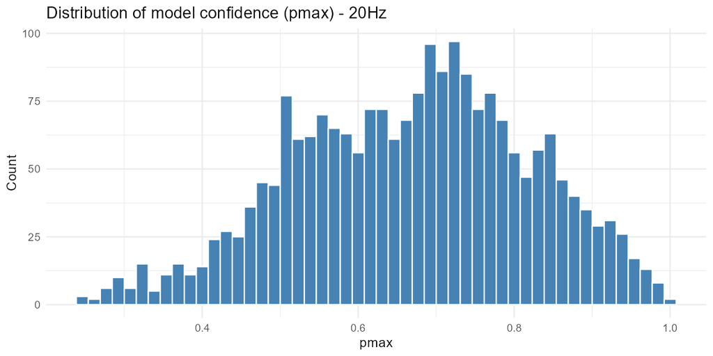

## 32.2. Corrección esperada frente a `pmax`

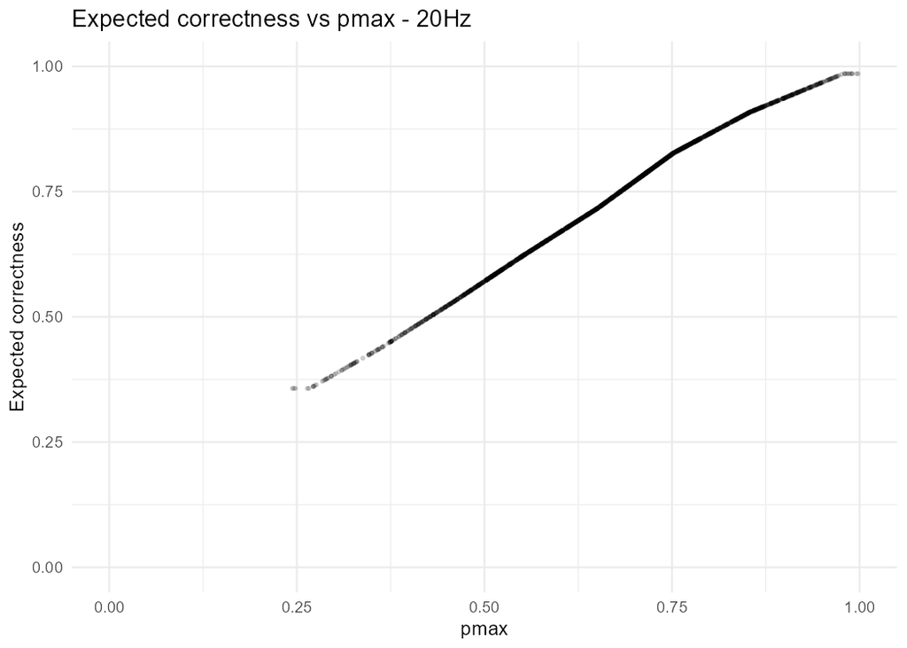

# 33. Ejemplo de tablas dinámicas con scroll

En un uso real, este documento puede leer directamente las salidas CSV ya exportadas por el script y mostrarlas como tablas interactivas.

[output not shown]

# 34. Conclusiones

El script **Free-ranging bustard classification — ROBUST UNIFIED SCRIPT** constituye una herramienta sólida para aplicar modelos cautivos a datos ACC de individuos en libertad. Su principal fortaleza es que no se limita a generar clases predichas, sino que construye un flujo completo y coherente desde la señal bruta hasta los productos ecológicamente interpretables.

Las mejoras metodológicas más importantes del script son:

- la unificación en un único pipeline de modos 20 Hz y 10 Hz;
- la incorporación de conversión de frecuencia con filtro Butterworth y decimación;
- la verificación estricta de bursts y ventanas;
- la extracción de *features* segura;
- la predicción probabilística robusta;
- la interpretación de confianza mediante calibración;
- la producción automática de presupuestos temporales y salidas exportables.

En conjunto, estas características hacen que el script sea más reproducible, más robusto ante errores de datos y más útil para aplicaciones reales en ecología del comportamiento.

# 35. Glosario

- **ACC**: datos de acelerometría.
- **Burst**: bloque fijo de señal continua; en este caso, 4 segundos.
- **Ventana**: subsegmento fijo de señal usado como observación analítica; aquí, 2 segundos.
- **20 Hz**: 20 muestras por segundo.
- **10 Hz**: 10 muestras por segundo.
- **Downsampling**: reducción de la frecuencia de muestreo.
- **Butterworth filter**: filtro paso bajo usado para reducir aliasing.
- **Decimation**: reducción de frecuencia conservando una de cada varias muestras.
- **Feature extraction**: conversión de la señal cruda en variables resumen.
- **Random Forest**: algoritmo de clasificación basado en múltiples árboles.
- **`pmax`**: probabilidad máxima predicha por el modelo.
- **Entropy**: medida de incertidumbre de la distribución completa de probabilidades.
- **Calibration**: relación entre confianza predicha y acierto observado.
- **Expected correctness**: estimación de la probabilidad de que la predicción sea correcta.
- **Time budget**: resumen porcentual del tiempo asignado a cada comportamiento.